# 23_Intro_to_Models

Week 13b Intro to Models

# Outline of class

Intro to modeling

1. Intro to basic linear modeling
2. Viewing results in base R, broom, and modelsummary
3. Running many models at the same time with purrr
4. Intro to tidy models

# Libraries

```r
library(tidyverse)
library(here)
library(palmerpenguins)
library(broom)
library(performance) # if you didn't already install from group projects install it
library(modelsummary)
library(tidymodels)
```

# Intro to basic linear modeling

## Anatomy of a basic linear model

To run a **simple linear model** you use the following formula:

`mod<-lm(y~x, data = df)`

lm = linear model  
y = dependent variable  
x = independent variable(s)  
df = dataframe  
You read this as *y is a function of x*

**Multiple regression**  
`mod<-lm(y~x1 + x2, data = df)`  
**Interaction term**  
`mod<-lm(y~x1*x2, data = df)` the * will compute x1+x2+x1:x2

## Model the penguin dataset

We’ve tidied and visualized the data and have our set of hypotheses that we want to test. Now we can start modeling…

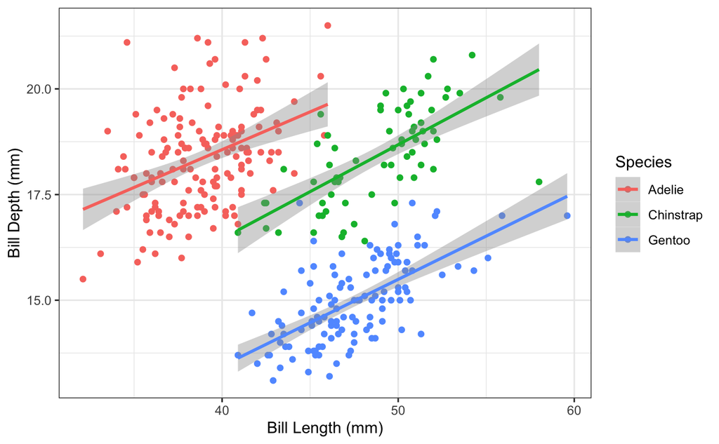

## Check model assumptions with performace

ALWAYS check the assumptions of your specific model. Make sure you know what your model is doing behind the scenes and that you meet all assumptions before interpreting your results. The [{performance}](https://github.com/easystats/performance) package makes this super easy.

```r
check_model(Peng_mod) # check assumptions of an lm model
```

[output not shown]

[output not shown]

# View results

## base R

### ANOVA Table

```r
anova(Peng_mod)
```

```
Analysis of Variance Table

Response: bill_length_mm
                       Df Sum Sq Mean Sq F value    Pr(>F)
bill_depth_mm           1  561.6   561.6  93.965 < 2.2e-16 ***
species                 2 7460.3  3730.2 624.151 < 2.2e-16 ***
bill_depth_mm:species   2  134.3    67.1  11.232 1.898e-05 ***
Residuals             336 2008.1     6.0
---
Signif. codes:  0 ‘***’ 0.001 ‘**’ 0.01 ‘*’ 0.05 ‘.’ 0.1 ‘ ’ 1
```

### Coefficients (effect size) with error

```r
summary(Peng_mod)
```

```
Call:
lm(formula = bill_length_mm ~ bill_depth_mm * species, data = penguins)

Residuals:
    Min      1Q  Median      3Q     Max
-7.7888 -1.5415  0.0575  1.5873 10.3590

Coefficients:
                               Estimate Std. Error t value Pr(>|t|)
(Intercept)                     23.0681     3.0165   7.647 2.18e-13 ***
bill_depth_mm                    0.8570     0.1641   5.224 3.08e-07 ***
speciesChinstrap                -9.6402     5.7154  -1.687 0.092590 .
speciesGentoo                   -5.8386     4.5353  -1.287 0.198850
bill_depth_mm:speciesChinstrap   1.0651     0.3100   3.435 0.000666 ***
bill_depth_mm:speciesGentoo      1.1637     0.2789   4.172 3.84e-05 ***
---
Signif. codes:  0 ‘***’ 0.001 ‘**’ 0.01 ‘*’ 0.05 ‘.’ 0.1 ‘ ’ 1

Residual standard error: 2.445 on 336 degrees of freedom
  (2 observations deleted due to missingness)
Multiple R-squared:  0.8024,    Adjusted R-squared:  0.7995
F-statistic: 272.9 on 5 and 336 DF,  p-value: < 2.2e-16
```

## broom

These results are not in a clean form and it is hard to extract specific values. Using [{broom}](https://cran.r-project.org/web/packages/broom/vignettes/broom.html) we can “tidy” the results so that it is easier to view and extract.

Functions that will clean up your results:

- `tidy()`
- `glance()`
- `augment()`

### tidy()

| term | estimate | std.error | statistic | p.value |
| --- | --- | --- | --- | --- |
| (Intercept) | 23.0680794 | 3.0165065 | 7.647283 | 2.180145e-13 |
| bill_depth_mm | 0.8570263 | 0.1640619 | 5.223797 | 3.081780e-07 |
| speciesChinstrap | -9.6401718 | 5.7154193 | -1.686695 | 9.259009e-02 |
| speciesGentoo | -5.8385785 | 4.5352593 | -1.287375 | 1.988497e-01 |
| bill_depth_mm:speciesChinstrap | 1.0650576 | 0.3100169 | 3.435483 | 6.656531e-04 |
| bill_depth_mm:speciesGentoo | 1.1637417 | 0.2789196 | 4.172319 | 3.843496e-05 |

### glance()

**glance** extracts R-squared, AICs, etc of the model

| r.squared | adj.r.squared | sigma | statistic | p.value | df | logLik | AIC | BIC | deviance | df.residual | nobs |
| --- | --- | --- | --- | --- | --- | --- | --- | --- | --- | --- | --- |
| 0.8024378 | 0.7994979 | 2.444663 | 272.946 | 5.68826e-116 | 5 | -787.9667 | 1589.933 | 1616.777 | 2008.063 | 336 | 342 |

### augment()

`augment()` add residuals and predicted values to your original data and requires that you put both the model and data

| .rownames | bill_length_mm | bill_depth_mm | species | .fitted | .resid | .hat | .sigma | .cooksd | .std.resid |
| --- | --- | --- | --- | --- | --- | --- | --- | --- | --- |
| 1 | 39.1 | 18.7 | Adelie | 39.09447 | 0.00552844 | 0.007185773 | 2.448309 | 6.213745e-09 | 0.002269601 |
| 2 | 39.5 | 17.4 | Adelie | 37.98034 | 1.51966266 | 0.010656073 | 2.446886 | 7.011447e-04 | 0.624963288 |
| 3 | 40.3 | 18.0 | Adelie | 38.49455 | 1.80544686 | 0.007162807 | 2.446307 | 6.605524e-04 | 0.741185054 |
| 5 | 36.7 | 19.3 | Adelie | 39.60869 | -2.90868735 | 0.010718410 | 2.443090 | 2.584016e-03 | -1.196239228 |
| 6 | 39.3 | 20.6 | Adelie | 40.72282 | -1.42282157 | 0.029496805 | 2.447037 | 1.768042e-03 | -0.590789702 |
| 7 | 38.9 | 17.8 | Adelie | 38.32315 | 0.57685213 | 0.007966926 | 2.448105 | 7.512391e-05 | 0.236909450 |
| 8 | 39.2 | 19.6 | Adelie | 39.86580 | -0.66579525 | 0.013700751 | 2.448035 | 1.741081e-04 | -0.274231476 |
| 9 | 34.1 | 18.1 | Adelie | 38.58026 | -4.48025577 | 0.006895861 | 2.435956 | 3.913949e-03 | -1.839019662 |
| 10 | 42.0 | 20.2 | Adelie | 40.38001 | 1.61998896 | 0.022097475 | 2.446673 | 1.691166e-03 | 0.670108662 |
| 11 | 37.8 | 17.1 | Adelie | 37.72323 | 0.07677055 | 0.013618728 | 2.448306 | 2.300631e-06 | 0.031619371 |

[output cut: 332 more lines]

## modelsummary

[{modelsummary}](https://vincentarelbundock.github.io/modelsummary/) creates tables and plots to summarize statistical models and data in `R`.

modelsummary includes two families of functions:

Model Summary  
`modelsummary`: Regression tables with side-by-side models.  
`modelsummary_wide`: Regression tables for categorical response models or grouped coefficients.  
`modelplot`: Coefficient plots.

Data Summary  
`datasummary`: Powerful tool to create (multi-level) cross-tabs and data summaries.  
`datasummary_balance`: Balance tables with subgroup statistics and difference in means (aka “Table 1”).  
`datasummary_correlation`: Correlation tables.  
`datasummary_skim`: Quick overview (“skim”) of a dataset.  
`datasummary_df`: Turn dataframes into nice tables with titles, notes, etc.

### Results in `modelsummary()`

**Export** summary tables to word, markdown, or tex document. You can also modify the tables to make them pub quality.

Let’s compare the Peng_mod with one that does not have species as an interaction term.

|  | Model with interaction | Model with no interaction |
| --- | --- | --- |
| (Intercept) | 23.068 | 55.067 |
|  | (3.017) | (2.516) |
| bill_depth_mm | 0.857 | -0.650 |
|  | (0.164) | (0.146) |
| speciesChinstrap | -9.640 |  |
|  | (5.715) |  |
| speciesGentoo | -5.839 |  |
|  | (4.535) |  |
| bill_depth_mm × speciesChinstrap | 1.065 |  |
|  | (0.310) |  |
| bill_depth_mm × speciesGentoo | 1.164 |  |
|  | (0.279) |  |
| Num.Obs. | 342 | 342 |
| R2 | 0.802 | 0.055 |
| R2 Adj. | 0.799 | 0.052 |
| AIC | 1589.9 | 2117.1 |
| BIC | 1616.8 | 2128.6 |
| Log.Lik. | -787.967 | -1055.559 |
| F | 272.946 | 19.884 |

### Modelplot()

Canned coefficient [modelplots](https://vincentarelbundock.github.io/modelsummary/articles/modelplot.html)

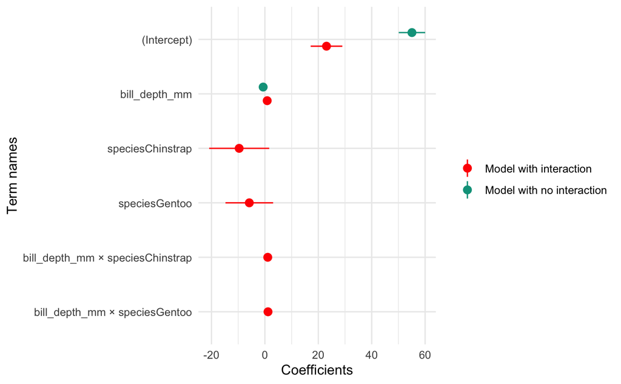

# Many models with purrr, dplyr, and broom

Let’s say you want to plot and compare lots of different models at the same time and view the results. For example, instead of using species as an interaction term, let’s make an individual model for every species.

We can essentially make a set of lists that have each dataset that we want to model and use the `map` functions to run the same model to every dataset. We will test it step by step

## nest()

First, let’s call the penguin data and create a list for the data by each species. We do this using `nest()`. We are going to nest the data by species.

```r
 models<- penguins %>%
  ungroup()%>% # the penguin data are grouped so we need to ungroup them #<<
    nest(-species) # nest all the data by species #<<

models
```

| species | data |
| --- | --- |
| Adelie |  |
| Gentoo |  |
| Chinstrap |  |

## map()

map a model to each of the groups in the list

```r
 models<- penguins %>%
  ungroup()%>% # the penguin data are grouped so we need to ungroup them
  nest(-species) %>% # nest all the data by species
  mutate(fit = map(data, ~lm(bill_length_mm~body_mass_g, data = .))) #<<

  models
```

| species | data | fit |
| --- | --- | --- |
| Adelie |  |  |
| Gentoo |  |  |
| Chinstrap |  |  |

```r
models$fit # shows you each of the 3 models
```

```
[[1]]

Call:
lm(formula = bill_length_mm ~ body_mass_g, data = .)

Coefficients:
(Intercept)  body_mass_g
  26.994139     0.003188


[[2]]

Call:
lm(formula = bill_length_mm ~ body_mass_g, data = .)

Coefficients:
(Intercept)  body_mass_g
  26.739548     0.004091


[[3]]

Call:
lm(formula = bill_length_mm ~ body_mass_g, data = .)

Coefficients:
(Intercept)  body_mass_g
  32.174193     0.004463
```

## view results

View the results. First, let’s mutate the models list so that we have a tidy coefficient dataframe (using `tidy()`) and a tidy model results dataframe (using `glance()`)

```r
results<-models %>%
   mutate(coeffs = map(fit, tidy), # look at the coefficients #<<
          modelresults = map(fit, glance))  # R2 and others #<<

results
```

| species | data | fit | coeffs | modelresults |
| --- | --- | --- | --- | --- |
| Adelie |  |  |  |  |
| Gentoo |  |  |  |  |
| Chinstrap |  |  |  |  |

Next, select what we want to show and unnest it to bring it back to a dataframe

| species | term | estimate | std.error | statistic | p.value | r.squared | adj.r.squared | sigma | statistic1 | p.value1 | df | logLik | AIC | BIC | deviance | df.residual | nobs |
| --- | --- | --- | --- | --- | --- | --- | --- | --- | --- | --- | --- | --- | --- | --- | --- | --- | --- |
| Adelie | (Intercept) | 26.994139137 | 1.4830932959 | 18.201241 | 1.058448e-39 | 0.3012537 | 0.2965641 | 2.233827 | 64.23905 | 2.954758e-13 | 1 | -334.6142 | 675.2283 | 684.2802 | 743.5072 | 149 | 151 |
| Adelie | body_mass_g | 0.003187876 | 0.0003977424 | 8.014926 | 2.954758e-13 | 0.3012537 | 0.2965641 | 2.233827 | 64.23905 | 2.954758e-13 | 1 | -334.6142 | 675.2283 | 684.2802 | 743.5072 | 149 | 151 |
| Gentoo | (Intercept) | 26.739548475 | 2.1065944410 | 12.693259 | 5.445720e-24 | 0.4477834 | 0.4432196 | 2.299612 | 98.11690 | 2.676014e-17 | 1 | -275.9483 | 557.8966 | 566.3331 | 639.8739 | 121 | 123 |
| Gentoo | body_mass_g | 0.004090871 | 0.0004129942 | 9.905398 | 2.676014e-17 | 0.4477834 | 0.4432196 | 2.299612 | 98.11690 | 2.676014e-17 | 1 | -275.9483 | 557.8966 | 566.3331 | 639.8739 | 121 | 123 |
| Chinstrap | (Intercept) | 32.174192865 | 3.4433622902 | 9.343830 | 1.070197e-13 | 0.2638244 | 0.2526702 | 2.886728 | 23.65252 | 7.480492e-06 | 1 | -167.5612 | 341.1225 | 347.7810 | 549.9911 | 66 | 68 |
| Chinstrap | body_mass_g | 0.004462694 | 0.0009176106 | 4.863385 | 7.480492e-06 | 0.2638244 | 0.2526702 | 2.886728 | 23.65252 | 7.480492e-06 | 1 | -167.5612 | 341.1225 | 347.7810 | 549.9911 | 66 | 68 |

# Other very common stats packages

- `stats`: General (`lm`)and generalized (`glm`) linear models (already loaded with base R)
- `lmer` : mixed effects models
- `lmerTest`’ : getting results from lmer
- `nlme` : non-linear mixed effects models
- `mgcv`, `gam` : generalized additive models
- `brms`, `rstan`, and many more : Bayesian modeling
- `lavaan`, `peicewiseSEM` : Structural Equation Models
- `rpart`, `randomForest`, `xgboost`, and more : Machine learning models

And so many more!

Check out [here](https://r4ds.had.co.nz/model-basics.html) for more modeling tips

Also, more info on nest models [here](https://www.kaylinpavlik.com/linear-regression-with-nested-data/) and [here](https://r4ds.had.co.nz/many-models.html)

# Intro to tidy models

{Tidymodels}

Like almost everything else there is a modeling package that uses the tidyverse language to create models. It is called [{tidymodels}](https://www.tidymodels.org/start/models/). For full transparency, I have not used it, but it looks cool and seems particularly useful for machine learning style modeling.

In tidymodels you start by specifying the *functional form* using the [parsnip package](https://tidymodels.github.io/parsnip/). In our case, we will use a *linear regression* which is coded like this:

```r
linear_reg()
```

```
Linear Regression Model Specification (regression)
```

Next, we need to set the *engine* for what type of linear regression we are modeling. For example, we could use an OLS regression or Bayesian or several other options. We will stick with OLS.

```r
lm_mod<-linear_reg() %>%
  set_engine("lm") #<<

lm_mod
```

[output not shown]

Next, we add the model fit.

```r
lm_mod<-linear_reg() %>%
  set_engine("lm") %>%
  fit(bill_length_mm ~ bill_depth_mm*species, data = penguins) #<<

lm_mod
```

[output not shown]

Lastly, we add the `tidy()` to it.  
And now we can pipe this into plots, etc. Nice, tidy way to model.

```r
lm_mod<-linear_reg() %>%
  set_engine("lm") %>%
  fit(bill_length_mm ~ bill_depth_mm*species, data = penguins) %>%
  tidy()#<<

lm_mod
```

[output not shown]

## Pipe to a plot

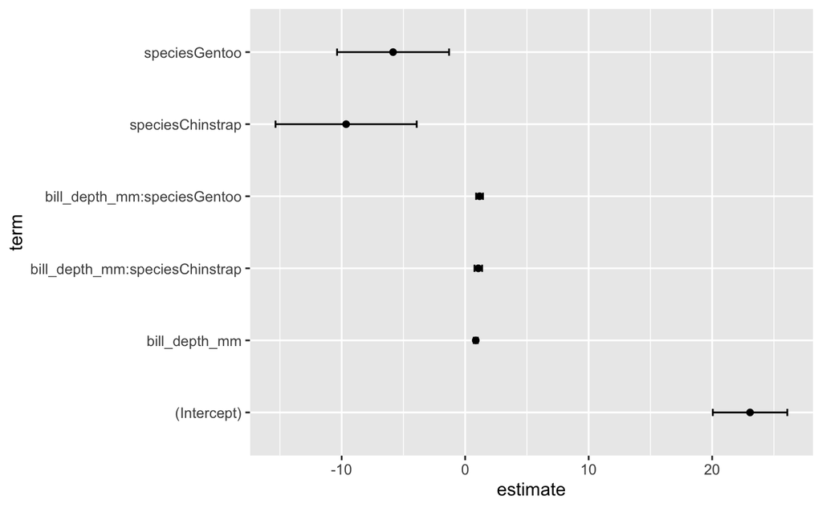

```r
lm_mod<-linear_reg() %>%
  set_engine("lm") %>%
  fit(bill_length_mm ~ bill_depth_mm*species, data = penguins) %>%
  tidy() %>%
  ggplot()+ #<<
    geom_point(aes(x = term, y = estimate))+ #<<
    geom_errorbar(aes(x = term, ymin = estimate-std.error, #<<
                      ymax = estimate+std.error), width = 0.1 )+ #<<
  coord_flip() #<<

lm_mod
```